# Analyse des données de circoncision

Étude descriptive et exploratoire

Author

Raed Mohamed Amine Hamrouni

Published

Today

# 1 Introduction

## 1.1 Contexte de l’étude

Ce document présente une analyse exhaustive d’un ensemble de données relatives aux interventions de circoncision. La circoncision est une procédure chirurgicale courante pratiquée pour des raisons culturelles, religieuses ou médicales. Cette analyse vise à fournir une compréhension approfondie des pratiques actuelles, des caractéristiques de la population concernée et des modalités opératoires.

## 1.2 Objectifs de l’analyse

Les objectifs principaux de cette étude sont :

- **Décrire la population** : caractériser les patients selon l’âge et la période d’intervention
- **Analyser les pratiques opératoires** : identifier les opérateurs, les contextes et les types d’anesthésie utilisés
- **Examiner les indications** : comprendre les raisons médicales et autres motivant les interventions
- **Explorer les tendances temporelles** : observer l’évolution du nombre d’interventions au fil des années
- **Identifier les facteurs associés** : mettre en évidence les relations entre différentes variables

## 1.3 Méthodologie

L’analyse repose sur des méthodes statistiques descriptives et exploratoires utilisant le langage R et les packages suivants :

- `dplyr` pour la manipulation des données
- `ggplot2` pour les visualisations
- `lubridate` pour le traitement des dates
- `forcats` pour la gestion des variables catégorielles

# 2 Inspection des données

## 2.1 Noms de colonnes

```r
names(data)
```

```
 [1] "Date"
 [2] "Âge.au.moment.de.la.circoncision..mois.années."
 [3] "age.en.jours"
 [4] "age.en.mois"
 [5] "age.en.année"
 [6] "État.nutritionnel"
 [7] "Indication.de.la.circoncision"
 [8] "Opérateur"
 [9] "Contexte"
[10] "Anesthésie"
[11] "Antécédent.d.infection.génito.urinaire..0.1."
[12] "Antécédent.de.prématurité..0.1."
[13] "Antécédent.de.chirurgie.urogénitale..0.1."
[14] "Hygiène.locale.préopératoire"
[15] "Utilisation.d.antibioprophylaxie..0.1."
```

[output cut: 26 more lines]

Le jeu de données contient plusieurs variables clés permettant une analyse multidimensionnelle des interventions.

## 2.2 Aperçu des premières observations

```r
head(data, 5)
```

```
        Date Âge.au.moment.de.la.circoncision..mois.années. age.en.jours
1 2020-12-31                                            416          416
2 2019-12-31                                           1728         1728
3 2019-12-31                                           2956         2956
4 2015-12-31                                           3521         3521
5 2014-12-31                                           3283         3283
  age.en.mois age.en.année État.nutritionnel Indication.de.la.circoncision
1          14            1       dénutrition                      médicale
2          57            5       dénutrition                    religieuse
3          97            8       dénutrition                         autre
4         116           10           obésité                         autre
5         108            9       dénutrition                    religieuse
                Opérateur Contexte Anesthésie
1                pediatre domicile     locale
2              chirurgien  cabinet     aucune
```

[output cut: 87 more lines]

## 2.3 Structure des données

```r
str(data)
```

```
'data.frame':   3709 obs. of  41 variables:
 $ Date                                                              : Date, format: "2020-12-31" "2019-12-31" ...
 $ Âge.au.moment.de.la.circoncision..mois.années.                    : int  416 1728 2956 3521 3283 3465 4253 342 2626 3723 ...
 $ age.en.jours                                                      : int  416 1728 2956 3521 3283 3465 4253 342 2626 3723 ...
 $ age.en.mois                                                       : int  14 57 97 116 108 114 140 11 86 122 ...
 $ age.en.année                                                      : int  1 5 8 10 9 9 12 1 7 10 ...
 $ État.nutritionnel                                                 : chr  "dénutrition" "dénutrition" "dénutrition" "obésité" ...
 $ Indication.de.la.circoncision                                     : chr  "médicale" "religieuse" "autre" "autre" ...
 $ Opérateur                                                         : chr  "pediatre" "chirurgien" "chirurgien" "circociseur traditionel" ...
 $ Contexte                                                          : chr  "domicile" "cabinet" "domicile" "cabinet" ...
 $ Anesthésie                                                        : chr  "locale" "aucune" "aucune" "générale" ...
 $ Antécédent.d.infection.génito.urinaire..0.1.                      : int  0 1 0 0 0 0 0 1 0 1 ...
 $ Antécédent.de.prématurité..0.1.                                   : int  0 0 0 0 1 0 0 0 0 1 ...
 $ Antécédent.de.chirurgie.urogénitale..0.1.                         : int  0 0 0 0 0 0 0 0 0 0 ...
 $ Hygiène.locale.préopératoire                                      : chr  "bonne" "mauvaise" "bonne" "mauvaise" ...
```

[output cut: 27 more lines]

**Interprétation** : Le jeu de données est structuré avec des variables numériques (âges) et catégorielles (opérateur, contexte, anesthésie, indication), ce qui permet une analyse à la fois quantitative et qualitative.

# 3 Analyses descriptives

## 3.1 Caractéristiques de l’âge

### 3.1.1 Statistiques résumées

```r
resume_age <- data %>%
  summarise(
    n = n(),
    age_median_jours = median(age_jours, na.rm = TRUE),
    age_Q1_jours = quantile(age_jours, 0.25, na.rm = TRUE),
    age_Q3_jours = quantile(age_jours, 0.75, na.rm = TRUE),
    age_median_mois = median(age_mois, na.rm = TRUE),
    age_moyen_mois = mean(age_mois, na.rm = TRUE),
    ecart_type_mois = sd(age_mois, na.rm = TRUE)
  )

resume_age %>% kable(digits = 1)
```

| n | age_median_jours | age_Q1_jours | age_Q3_jours | age_median_mois | age_moyen_mois | ecart_type_mois |
| --- | --- | --- | --- | --- | --- | --- |
| 3709 | 2228 | 1165 | 3294 | 73 | 73.4 | 40.7 |

### 3.1.2 Distribution de l’âge (en mois)

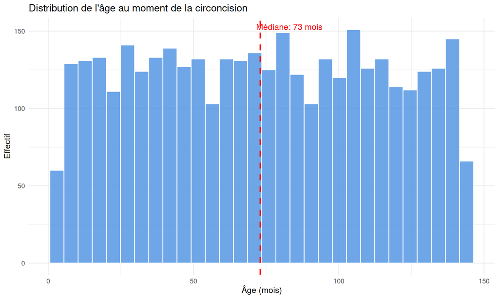

```r
ggplot(data, aes(x = age_mois)) +
  geom_histogram(bins = 30, fill = "#4a90e2", color = "white", alpha = 0.8) +
  geom_vline(aes(xintercept = median(age_mois, na.rm = TRUE)),
             color = "red", linetype = "dashed", size = 1) +
  annotate("text", x = median(data$age_mois, na.rm = TRUE) + 10,
           y = Inf, label = paste("Médiane:", round(median(data$age_mois, na.rm = TRUE), 1), "mois"),
           vjust = 2, color = "red") +
  labs(title = "Distribution de l'âge au moment de la circoncision",
       x = "Âge (mois)", y = "Effectif") +
  theme_minimal(base_size = 12)
```

# 4 Évolution temporelle

## 4.1 Tendance annuelle des interventions

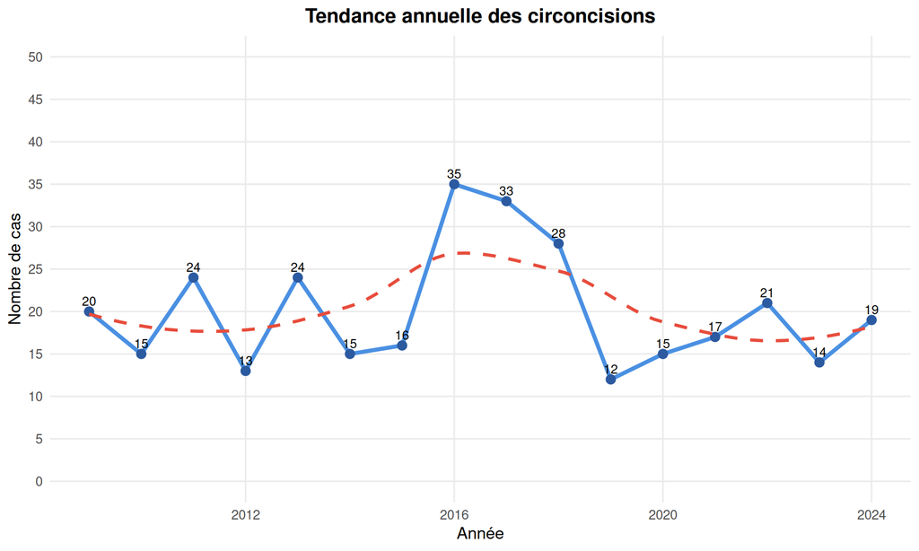

Figure 2: Évolution du nombre de circoncisions par année, révélant les tendances et variations dans la pratique chirurgicale.

```r
cas_par_annee <- data %>%
  group_by(annee) %>%
  summarise(n = n())

ggplot(cas_par_annee, aes(x = annee, y = n)) +
  geom_line(color = "#4a90e2", linewidth = 1.5) +
  geom_point(color = "#2c5aa0", size = 3) +
  geom_text(aes(label = n), vjust = -0.6, size = 3.5) +
  geom_smooth(method = "loess", se = FALSE,
              color = "#e74c3c", linetype = "dashed") +
  scale_y_continuous(
    limits = c(0, 50),
    breaks = seq(0, 50, 5)
  ) +
  labs(
    title = "Tendance annuelle des circoncisions",
    x = "Année",
    y = "Nombre de cas"
  ) +
  theme_minimal(base_size = 13) +
  theme(
    panel.grid.minor = element_blank(),
    plot.title = element_text(hjust = 0.5, face = "bold")
  )
```

**Analyse temporelle** :

- La courbe de tendance (en rouge) permet d’identifier les périodes de croissance ou de décroissance
- Les variations annuelles peuvent refléter des changements dans la demande, la disponibilité des services ou des facteurs sociodémographiques
- Une analyse plus approfondie nécessiterait la prise en compte de facteurs externes (politiques de santé, événements sociétaux)

# 5 Analyse par opérateur

## 5.1 Distribution des interventions par praticien

```r
operateurs_stats <- data %>%
  count(operateur, sort = TRUE) %>%
  mutate(
    pourcentage = round(100 * n / sum(n), 1),
    pourcentage_cumul = cumsum(pourcentage)
  )

operateurs_stats %>%
  head(10) %>%
  kable(col.names = c("Opérateur", "Nombre", "Pourcentage (%)", "Cumulé (%)"))
```

| Opérateur | Nombre | Pourcentage (%) | Cumulé (%) |
| --- | --- | --- | --- |
| resident generaliste | 964 | 26.0 | 26.0 |
| chirurgien | 947 | 25.5 | 51.5 |
| circociseur traditionel | 925 | 24.9 | 76.4 |
| pediatre | 873 | 23.5 | 99.9 |

## 5.2 Visualisation des principaux opérateurs

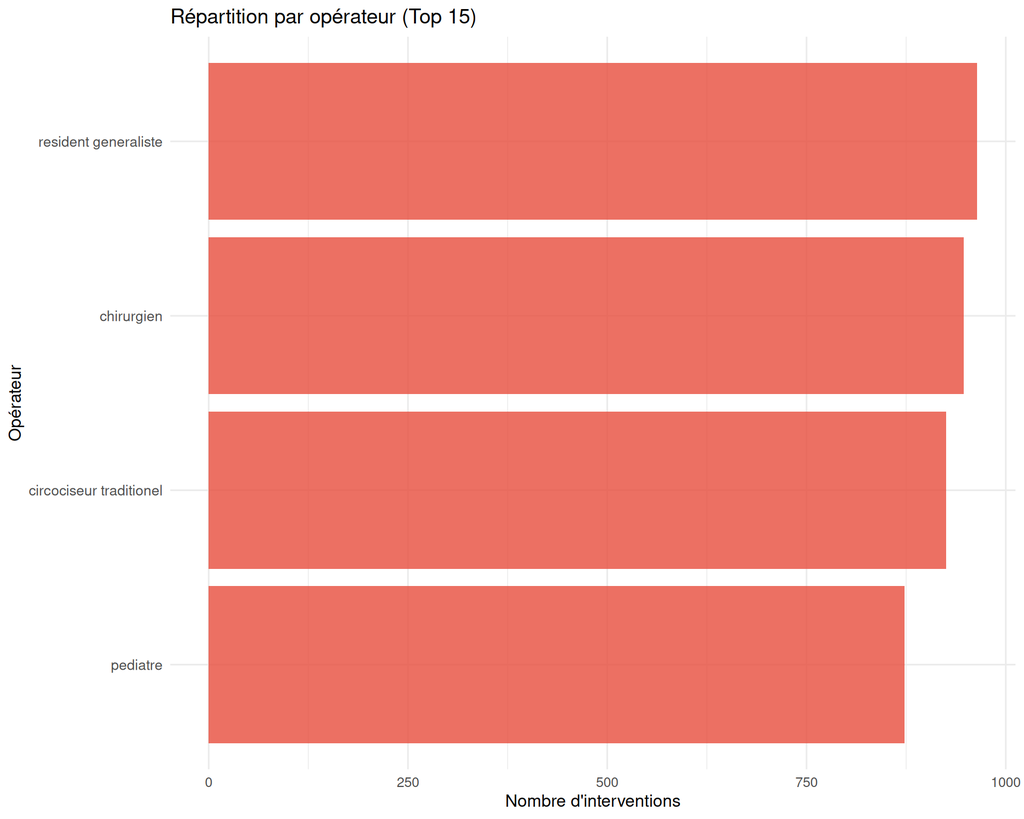

```r
top_operateurs <- data %>%
  count(operateur, sort = TRUE) %>%
  head(15)

data %>%
  filter(operateur %in% top_operateurs$operateur) %>%
  ggplot(aes(x = fct_reorder(operateur, operateur, .fun = length))) +
  geom_bar(fill = "#e74c3c", alpha = 0.8) +
  coord_flip() +
  labs(title = "Répartition par opérateur (Top 15)",
       x = "Opérateur", y = "Nombre d'interventions") +
  theme_minimal(base_size = 12) +
  theme(axis.text.y = element_text(size = 10))
```

# 6 Analyse du contexte

## 6.1 Répartition selon le contexte d’intervention

```r
contexte_stats <- data %>%
  count(contexte, sort = TRUE) %>%
  mutate(pourcentage = round(100 * n / sum(n), 1))

contexte_stats %>% kable(col.names = c("Contexte", "Nombre", "Pourcentage (%)"))
```

| Contexte | Nombre | Pourcentage (%) |
| --- | --- | --- |
| cabinet | 1250 | 33.7 |
| hôpital | 1241 | 33.5 |
| domicile | 1218 | 32.8 |

**Analyse contextuelle** : Le contexte d’intervention (ambulatoire, hospitalier, cabinet privé, etc.) influence les modalités opératoires, le suivi post-opératoire et potentiellement les résultats cliniques.

## 6.2 Visualisation par contexte

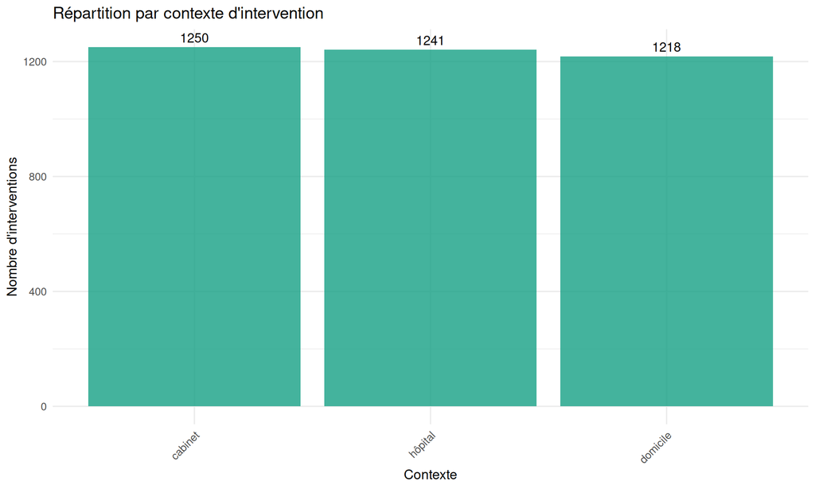

Figure 4: Distribution des interventions selon le contexte, reflétant l’organisation des soins.

```r
ggplot(data, aes(x = fct_infreq(contexte))) +
  geom_bar(fill = "#16a085", alpha = 0.8) +
  geom_text(stat = "count", aes(label = after_stat(count)), vjust = -0.5, size = 4) +
  labs(title = "Répartition par contexte d'intervention",
       x = "Contexte", y = "Nombre d'interventions") +
  theme_minimal(base_size = 12) +
  theme(axis.text.x = element_text(angle = 45, hjust = 1))
```

# 7 Analyse de l’anesthésie

## 7.1 Types d’anesthésie pratiqués

```r
anesthesie_stats <- data %>%
  count(anesthesie, sort = TRUE) %>%
  mutate(pourcentage = round(100 * n / sum(n), 1))

anesthesie_stats %>% kable(col.names = c("Type d'anesthésie", "Nombre", "Pourcentage (%)"))
```

| Type d’anesthésie | Nombre | Pourcentage (%) |
| --- | --- | --- |
| locale | 1281 | 34.5 |
| aucune | 1220 | 32.9 |
| générale | 1208 | 32.6 |

**Considérations cliniques** : Le choix de l’anesthésie dépend de l’âge du patient, du contexte chirurgical, de l’expérience de l’opérateur et des ressources disponibles. L’anesthésie locale est souvent privilégiée pour les nourrissons, tandis que l’anesthésie générale peut être nécessaire pour les enfants plus âgés.

## 7.2 Visualisation des pratiques anesthésiques

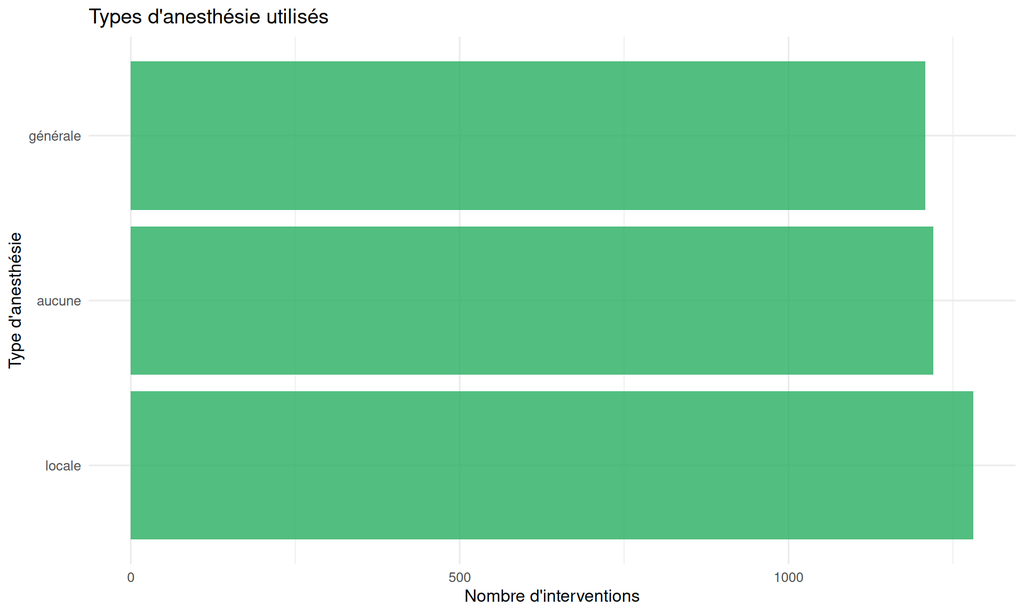

Figure 5: Répartition des types d’anesthésie utilisés lors des circoncisions.

```r
ggplot(data, aes(x = fct_infreq(anesthesie))) +
  geom_bar(fill = "#27ae60", alpha = 0.8) +
  coord_flip() +
  labs(title = "Types d'anesthésie utilisés",
       x = "Type d'anesthésie", y = "Nombre d'interventions") +
  theme_minimal(base_size = 12)
```

# 8 Indications de la circoncision

## 8.1 Principales indications médicales et autres

```r
indications_stats <- data %>%
  count(indication, sort = TRUE) %>%
  mutate(pourcentage = round(100 * n / sum(n), 1))

indications_stats %>%
  head(10) %>%
  kable(col.names = c("Indication", "Nombre", "Pourcentage (%)"))
```

| Indication | Nombre | Pourcentage (%) |
| --- | --- | --- |
| médicale | 1246 | 33.6 |
| autre | 1244 | 33.5 |
| religieuse | 1219 | 32.9 |

**Analyse des indications** : Les indications peuvent être classées en plusieurs catégories :

- **Indications médicales** : phimosis, infections récurrentes, balanite
- **Indications culturelles/religieuses** : pratiques traditionnelles
- **Indications préventives** : hygiène, prévention des infections
- **Autres indications** : esthétiques ou convenance personnelle

## 8.2 Visualisation des principales indications

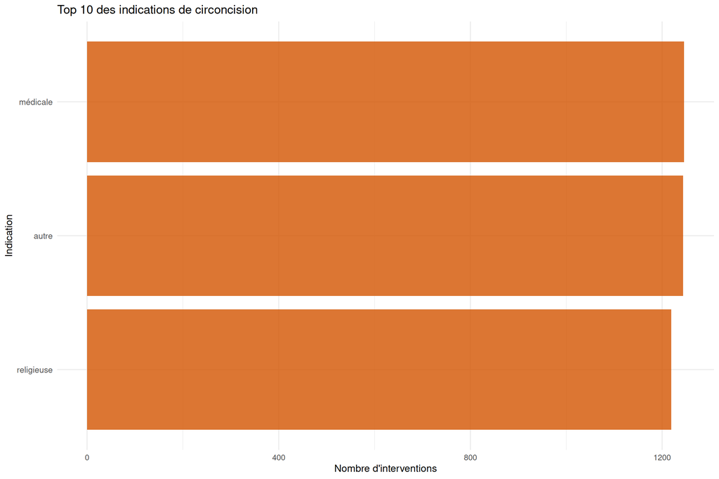

```r
top_indications <- data %>%
  count(indication, sort = TRUE) %>%
  head(10)

data %>%
  filter(indication %in% top_indications$indication) %>%
  ggplot(aes(x = fct_reorder(indication, indication, .fun = length))) +
  geom_bar(fill = "#d35400", alpha = 0.8) +
  coord_flip() +
  labs(title = "Top 10 des indications de circoncision",
       x = "Indication", y = "Nombre d'interventions") +
  theme_minimal(base_size = 12) +
  theme(axis.text.y = element_text(size = 10))
```

# 9 Analyses croisées

## 9.1 Âge selon le contexte

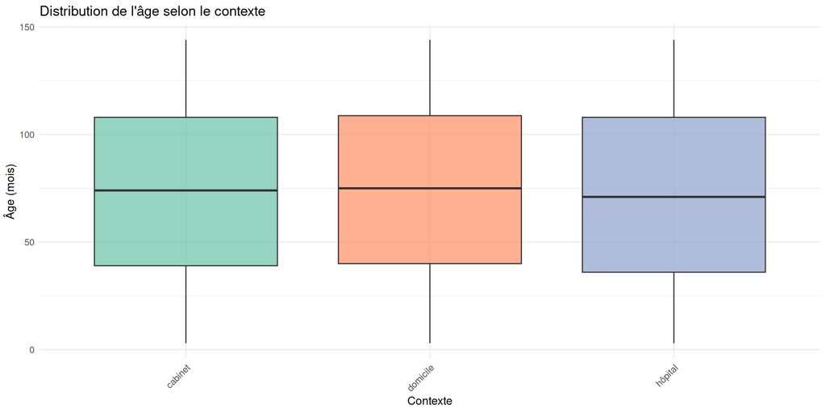

Figure 7: Comparaison des distributions d’âge selon le contexte d’intervention.

```r
data %>%
  filter(!is.na(contexte) & !is.na(age_mois)) %>%
  ggplot(aes(x = contexte, y = age_mois, fill = contexte)) +
  geom_boxplot(alpha = 0.7) +
  labs(title = "Distribution de l'âge selon le contexte",
       x = "Contexte", y = "Âge (mois)") +
  theme_minimal(base_size = 12) +
  theme(axis.text.x = element_text(angle = 45, hjust = 1),
        legend.position = "none") +
  scale_fill_brewer(palette = "Set2")
```

# 10 Conclusion

## 10.2 Implications pratiques

### 10.2.2 Pour la santé publique

- Les données permettent d’évaluer l’offre de soins et d’identifier d’éventuels besoins non satisfaits
- L’analyse des tendances temporelles aide à la planification des ressources
- La documentation des indications contribue à l’amélioration des pratiques

## 10.3 Limites de l’étude

Cette analyse présente certaines limitations :

- **Nature descriptive** : absence d’analyses inférentielles ou prédictives
- **Données manquantes** : possibles valeurs manquantes non explorées en détail
- **Absence de suivi** : pas d’information sur les complications ou les résultats à long terme
- **Contexte local** : les résultats peuvent ne pas être généralisables à d’autres contextes

## 10.4 Perspectives et recommandations

### 10.4.1 Analyses futures

- **Modélisation prédictive** : développer des modèles pour anticiper les besoins
- **Analyse des complications** : si les données sont disponibles, étudier les facteurs de risque
- **Comparaisons** : benchmarking avec d’autres établissements ou régions
- **Séries temporelles** : analyses plus sophistiquées des tendances

### 10.4.2 Amélioration de la collecte de données

- Standardisation des variables (nomenclature, codage)
- Enrichissement avec des données de suivi post-opératoire
- Documentation systématique des complications et événements indésirables
- Collecte de données sur la satisfaction des patients/familles

### 10.4.3 Impact clinique

Cette analyse constitue une base solide pour :

- L’audit des pratiques professionnelles
- L’amélioration continue de la qualité des soins
- La formation des nouveaux praticiens
- L’information des patients et de leurs familles

## 10.5 Conclusion finale

Cette analyse descriptive pose les fondations pour des travaux ultérieurs plus approfondis, notamment des études analytiques explorant les facteurs associés aux résultats cliniques, ou des recherches comparatives évaluant différentes techniques et protocoles.

La documentation systématique et l’analyse régulière de telles données constituent des outils essentiels pour garantir la qualité et la sécurité des soins chirurgicaux pédiatriques.

**Date de l’analyse** : 2025-12-18

**Outils utilisés** : R version 4.5.2, Quarto, packages tidyverse

# 11 Annexes

## 11.1 Code complet de l’analyse

Le code source complet est disponible en dépliant les sections de code tout au long du document (utiliser les boutons “Code” en haut à droite de chaque bloc).

## 11.2 Références

- Méthodologie d’analyse descriptive en R
- Documentation des packages utilisés : dplyr, ggplot2, lubridate
- Bonnes pratiques en visualisation de données

## 11.3 Contact

Pour toute question concernant cette analyse, veuillez contacter : Raed Mohamed Amine Hamrouni